# CourseProject

wpmcdonald

August 22, 2014

## Background

Using devices such as Jawbone Up, Nike FuelBand, and Fitbit it is now possible to collect a large amount of data about personal activity relatively inexpensively. These type of devices are part of the quantified self movement – a group of enthusiasts who take measurements about themselves regularly to improve their health, to find patterns in their behavior, or because they are tech geek. One thing that people regularly do is quantify how much of a particular activity they do, but they rarely quantify how well they do it. In this project, your goal will be to use data from accelerometers on the belt, forearm, arm, and dumbell of 6 participants. They were asked to perform barbell lifts correctly and incorrectly in 5 different ways. More information is available from the website here: http://groupware.les.inf.puc-rio.br/har (see the section on the Weight Lifting Exercise Dataset).

The data for this project and the original paper describing the experiment are available [here](http://groupware.les.inf.puc-rio.br/har).

## Loading data and Libraries

```r
library(caret, quietly = T)
library(randomForest, quietly = T)
```

```r
library(corrplot, quietly = T)
library(dplyr, quietly = T)
set.seed(1234)
```

```r
train <- read.csv("pml-training.csv", na.strings=c("NA", "#DIV/0!", ""), strip.white = T)
test <- read.csv("pml-testing.csv", na.strings=c("NA","#DIV/0!",""), strip.white = T)
dim(train)
```

```
## [1] 19622   160
```

### Data Preprocessing

Many columns consisisst entirely of NA’s and are not germaine to the analysis so we will remove all columns with NA values

```r
train <- train[ ,apply(train, 2, function(x) sum(is.na(x)) == 0)]
test <- test[ ,apply(test, 2, function(x) sum(is.na(x)) == 0)]
```

In addition, the first 7 columns contain personal data and other non useful information for this anaysis.

```r
train <- train[, 8:60]
test <- test[, 8:60]
dim(train)
```

```
## [1] 19622    53
```

```r
dim(test)
```

```
## [1] 20 53
```

Next, it is possible that some of the variables are highly correlated and will not add any useful information to the analysis. Plot and check for highly correlated columns and remove any with correlation values greater than 90%

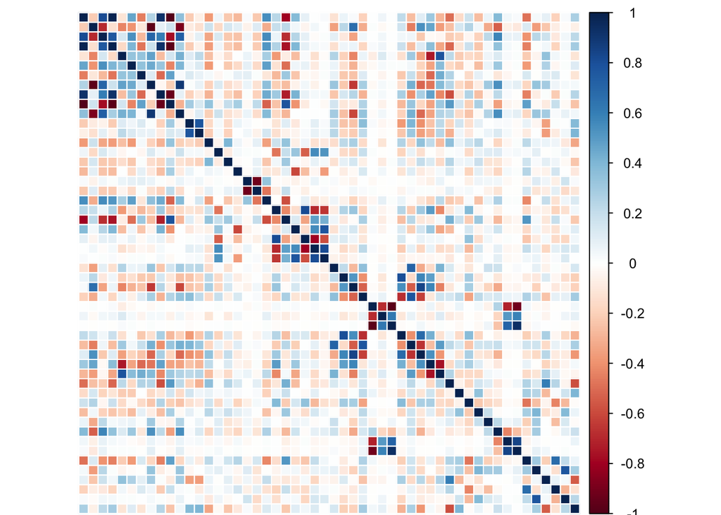

```r
CorrelationCheck <- cor(select(train,-classe))
corrplot(CorrelationCheck, method="color", tl.pos="n")
```

```r
HighlyCorrelated <- findCorrelation(CorrelationCheck, cutoff = 0.90)
train <- train[,-HighlyCorrelated]

dim(train)
```

```
## [1] 19622    46
```

### Training a model

Given the large number of predictors, I have chosen to use the Random Forests algorithm to develop a model.

```r
model <- randomForest(classe ~ ., data = train)
model
```

```
##
## Call:
##  randomForest(formula = classe ~ ., data = train)
##                Type of random forest: classification
##                      Number of trees: 500
## No. of variables tried at each split: 6
##
##         OOB estimate of  error rate: 0.3%
## Confusion matrix:
##      A    B    C    D    E class.error
## A 5578    1    0    0    1   0.0003584
## B    8 3786    3    0    0   0.0028970
## C    0   13 3408    1    0   0.0040912
## D    0    0   22 3192    2   0.0074627
## E    0    0    2    6 3599   0.0022179
```

The OOB error rate estimate is very low at 0.3% and looking at the confusion matrix seems to indicate that the prediction model is very good

```r
imp <- varImp(model)
imp$Variable <- row.names(imp)
imp[order(imp$Overall, decreasing = T),]
```

```
##                      Overall             Variable
## yaw_belt             1144.02             yaw_belt
## magnet_dumbbell_z     842.70    magnet_dumbbell_z
## pitch_belt            839.59           pitch_belt
## pitch_forearm         781.03        pitch_forearm
## magnet_dumbbell_y     722.28    magnet_dumbbell_y
## roll_forearm          634.36         roll_forearm
## magnet_belt_z         550.81        magnet_belt_z
## magnet_dumbbell_x     545.63    magnet_dumbbell_x
## magnet_belt_y         542.65        magnet_belt_y
## gyros_belt_z          445.60         gyros_belt_z
## accel_dumbbell_y      441.24     accel_dumbbell_y
## roll_dumbbell         421.91        roll_dumbbell
## accel_dumbbell_z      370.30     accel_dumbbell_z
## roll_arm              367.59             roll_arm
## total_accel_belt      361.73     total_accel_belt
## accel_forearm_x       341.67      accel_forearm_x
## magnet_forearm_z      324.27     magnet_forearm_z
## total_accel_dumbbell  314.47 total_accel_dumbbell
## magnet_belt_x         310.61        magnet_belt_x
## yaw_dumbbell          299.30         yaw_dumbbell
## accel_forearm_z       292.60      accel_forearm_z
## gyros_dumbbell_y      285.81     gyros_dumbbell_y
## accel_arm_x           272.19          accel_arm_x
## accel_dumbbell_x      270.58     accel_dumbbell_x
## yaw_arm               270.51              yaw_arm
## magnet_arm_x          264.85         magnet_arm_x
## magnet_arm_y          262.56         magnet_arm_y
## magnet_forearm_y      255.12     magnet_forearm_y
## magnet_forearm_x      239.87     magnet_forearm_x
## magnet_arm_z          210.67         magnet_arm_z
## pitch_arm             206.39            pitch_arm
## pitch_dumbbell        197.46       pitch_dumbbell
## yaw_forearm           197.18          yaw_forearm
## accel_arm_y           194.51          accel_arm_y
## gyros_arm_x           175.89          gyros_arm_x
## accel_forearm_y       166.31      accel_forearm_y
## accel_arm_z           163.68          accel_arm_z
## gyros_forearm_y       162.45      gyros_forearm_y
## gyros_belt_y          152.07         gyros_belt_y
## gyros_belt_x          141.17         gyros_belt_x
## total_accel_forearm   133.16  total_accel_forearm
## total_accel_arm       119.37      total_accel_arm
## gyros_dumbbell_z      108.32     gyros_dumbbell_z
## gyros_forearm_x        95.07      gyros_forearm_x
## gyros_arm_z            72.44          gyros_arm_z
```

## Test Set Prediction

Finally wee need to apply the model to the test set of 20 observations

```r
predict(model, newdata = test)
```

```
##  1  2  3  4  5  6  7  8  9 10 11 12 13 14 15 16 17 18 19 20
##  B  A  B  A  A  E  D  B  A  A  B  C  B  A  E  E  A  B  B  B
## Levels: A B C D E
```

## Conclusion

The Random Forest model predicts the trainng set with very good accuracy with an out of bag error estimate of approximately 0.3 %